# Project_2

Lin_Deng

```r
library(tidyverse)
library(ggplot2)
library(reshape)
library(corrplot)
library(caret)
library(mlr)
library(e1071)
library(ROSE)
library(rpart)
library(randomForest)
library(data.table)
library(gbm)
```

# I. Introduction

The main purpose of this project using several **Machine Learning** methods to determine the income level for the person represented by the record.

This dataset can be downloaded from *[UCI Machines Learning Repository](http://archive.ics.uci.edu/ml/machine-learning-databases/census-income-mld/)*

And here is the detailed dataset *[describtion](http://archive.ics.uci.edu/ml/machine-learning-databases/census-income-mld/census-income.names)*

```r
rm(list = ls())

training.data  <- read.table("F:/2018_spring_semester_master/IE_5561_Data Driven Decision/Assignment/Project_2/train.csv", header = TRUE, sep = ",")

test.data <- read.table("F:/2018_spring_semester_master/IE_5561_Data Driven Decision/Assignment/Project_2/test.csv", header = TRUE, sep = ",")

table(is.na(training.data))
```

```
##
##   FALSE    TRUE
## 7763852  416591
```

```r
table(is.na(test.data))
```

```
##
##   FALSE
## 4090242
```

```r
dim(training.data)
```

```
## [1] 199523     41
```

```r
dim(test.data)
```

```
## [1] 99762    41
```

```r
str(test.data)
```

```
## 'data.frame':    99762 obs. of  41 variables:
##  $ age                             : int  38 44 2 35 49 13 1 61 38 7 ...
##  $ class_of_worker                 : Factor w/ 9 levels " Federal government",..: 5 7 4 5 5 4 4 4 5 4 ...
##  $ industry_code                   : int  6 37 0 29 4 0 0 0 45 0 ...
##  $ occupation_code                 : int  36 12 0 3 34 0 0 0 12 0 ...
##  $ education                       : Factor w/ 17 levels " 10th grade",..: 4 9 11 13 13 11 11 13 15 11 ...
##  $ wage_per_hour                   : int  0 0 0 0 0 0 0 0 0 0 ...
##  $ enrolled_in_edu_inst_lastwk     : Factor w/ 3 levels " College or university",..: 3 3 3 3 3 3 3 3 3 3 ...
##  $ marital_status                  : Factor w/ 7 levels " Divorced"," Married-A F spouse present",..: 3 3 5 1 1 5 5 3 3 5 ...
##  $ major_industry_code             : Factor w/ 24 levels " Agriculture",..: 11 3 15 22 5 15 15 15 16 15 ...
##  $ major_occupation_code           : Factor w/ 15 levels " Adm support including clerical",..: 6 11 7 3 9 7 7 7 11 7 ...
##  $ race                            : Factor w/ 5 levels " Amer Indian Aleut or Eskimo",..: 5 5 5 5 5 5 5 5 3 5 ...
##  $ hispanic_origin                 : Factor w/ 10 levels " All other"," Central or South American",..: 7 1 6 1 1 1 6 1 1 1 ...
##  $ sex                             : Factor w/ 2 levels " Female"," Male": 1 1 2 1 2 2 1 1 2 1 ...
##  $ member_of_labor_union           : Factor w/ 3 levels " No"," Not in universe",..: 2 2 2 2 2 2 2 2 2 2 ...
```

[output cut: 27 more lines]

Let’s check the levels of **income_level** in both dataset.

```r
unique(training.data$income_level)
```

```
## [1] -50000  50000
```

```r
unique(test.data$income_level)
```

```
## [1] -50000    50000+.
## Levels: -50000  50000+.
```

In training data, income levels are *50000* and *-50000* more than $50000 a year and less than $50000 a year; In test data, income levels are *50000+* and *-50000* more than $50000 a year and less than $50000 a year.

Then replace them by 0 & 1.

```r
training.data$income_level <- as.character(ifelse(training.data$income_level == -50000, 0, 1))
test.data$income_level <- as.character(ifelse(test.data$income_level == -50000, 0, 1))
```

# II. Data Separation

According to the describtion of the variables in dataset, we can divide them into 2 categories – nominal and contiuous.

Now I need to separate them

```r
cont_var <- c(1, 6, 17, 18, 19, 30, 39, 41)
nom_var <- setdiff(1:40, cont_var)
cont_training <- training.data[, c(cont_var)]
nom_training <- training.data[, nom_var]

cont_test <- test.data[, c(cont_var)]
nom_test <- test.data[, c(nom_var)]

head(cont_training)
```

```
##   age wage_per_hour capital_gains capital_losses dividend_from_Stocks
## 1  73             0             0              0                    0
## 2  58             0             0              0                    0
## 3  18             0             0              0                    0
## 4   9             0             0              0                    0
## 5  10             0             0              0                    0
## 6  48          1200             0              0                    0
##   num_person_Worked_employer weeks_worked_in_year income_level
## 1                          0                    0            0
## 2                          1                   52            0
## 3                          0                    0            0
## 4                          0                    0            0
## 5                          0                    0            0
## 6                          1                   52            0
```

```r
head(nom_training)
```

```
##                  class_of_worker industry_code occupation_code
## 1                Not in universe             0               0
## 2 Self-employed-not incorporated             4              34
## 3                Not in universe             0               0
## 4                Not in universe             0               0
## 5                Not in universe             0               0
## 6                        Private            40              10
##                    education enrolled_in_edu_inst_lastwk
## 1       High school graduate             Not in universe
## 2 Some college but no degree             Not in universe
## 3                 10th grade                 High school
## 4                   Children             Not in universe
## 5                   Children             Not in universe
## 6 Some college but no degree             Not in universe
##                    marital_status         major_industry_code
```

[output cut: 76 more lines]

# III. Basic Visualization

Visualize plots of age versus other variables

1. age~ wage_per_hour

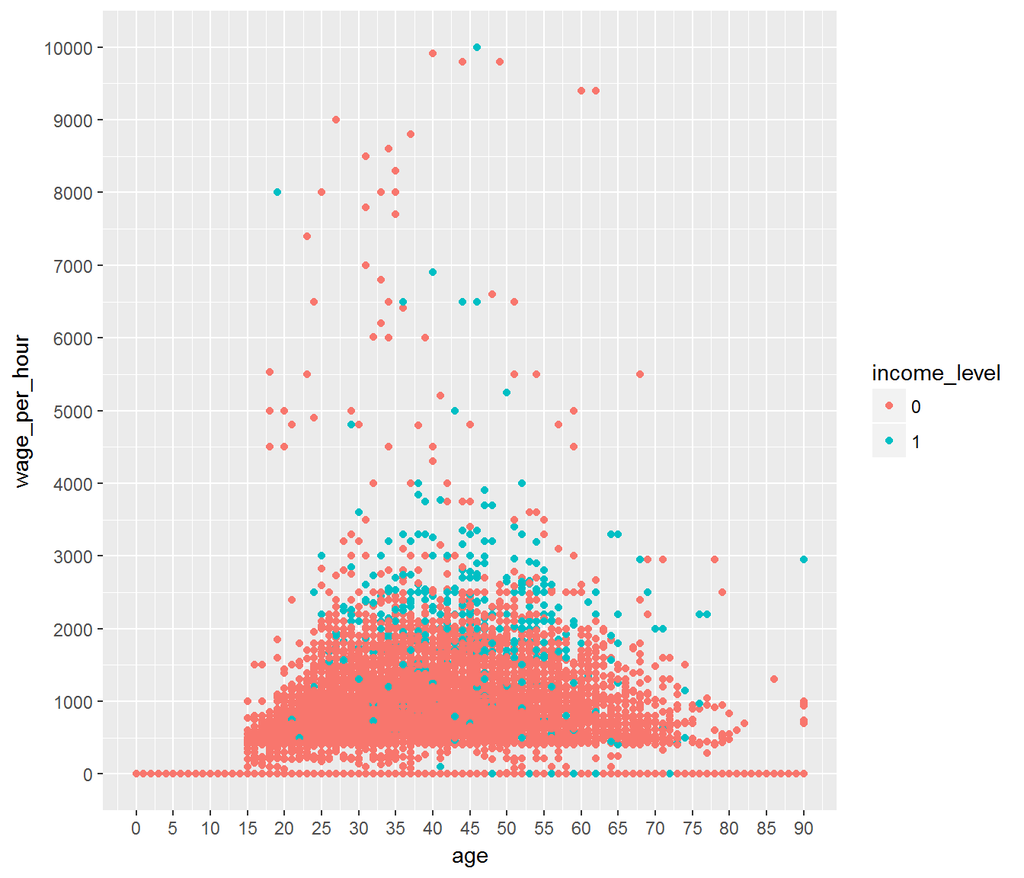

```r
## age~ wage_per_hour
ggplot(cont_training) +
  geom_point(aes(x = age, y = wage_per_hour, color = income_level)) +
  scale_y_continuous(breaks = seq(0,10000,1000)) +
  scale_x_continuous(breaks = seq(0, 100, 5))
```

According to the graph of wage_per_hour versus people’s age , we may find that for most of the people their wage per hour is under $2000 per hour.

2. age~ captial_gains

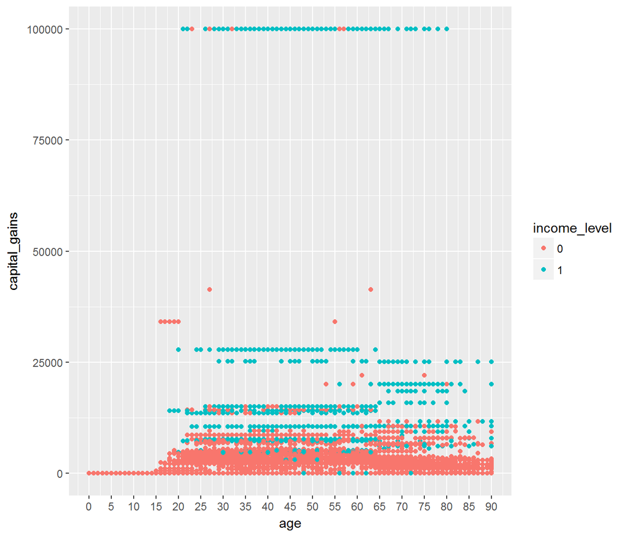

```r
ggplot(cont_training) +
  geom_point(aes(x = age, y = capital_gains, color = income_level)) +
  scale_x_continuous(breaks = seq(0, 100, 5))
```

3.age~ captial_losses

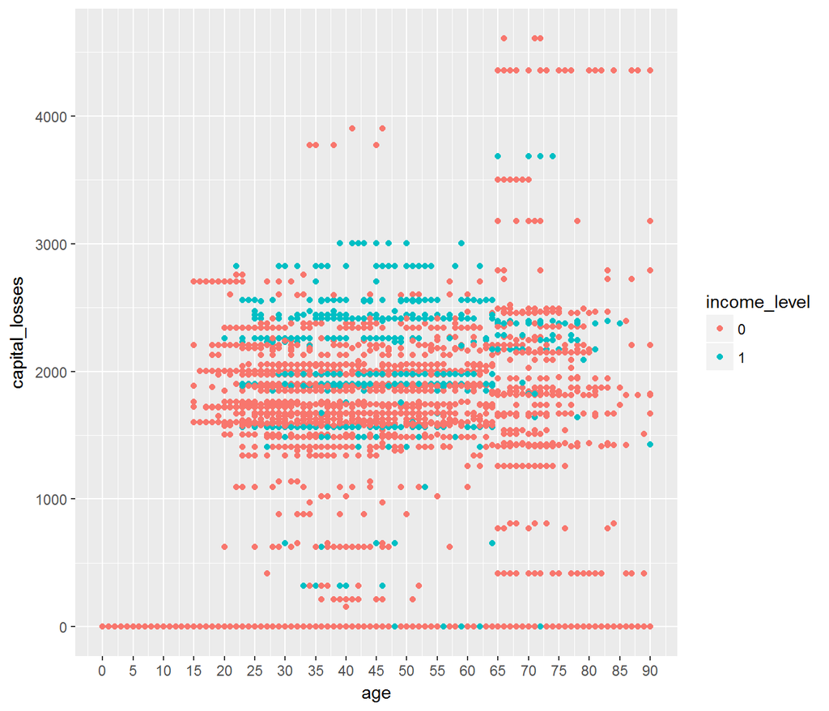

```r
ggplot(cont_training) +
  geom_point(aes(x = age, y = capital_losses, color = income_level)) +
  scale_x_continuous(breaks = seq(0, 100, 5))
```

4. age~ dividend_from_Stocks

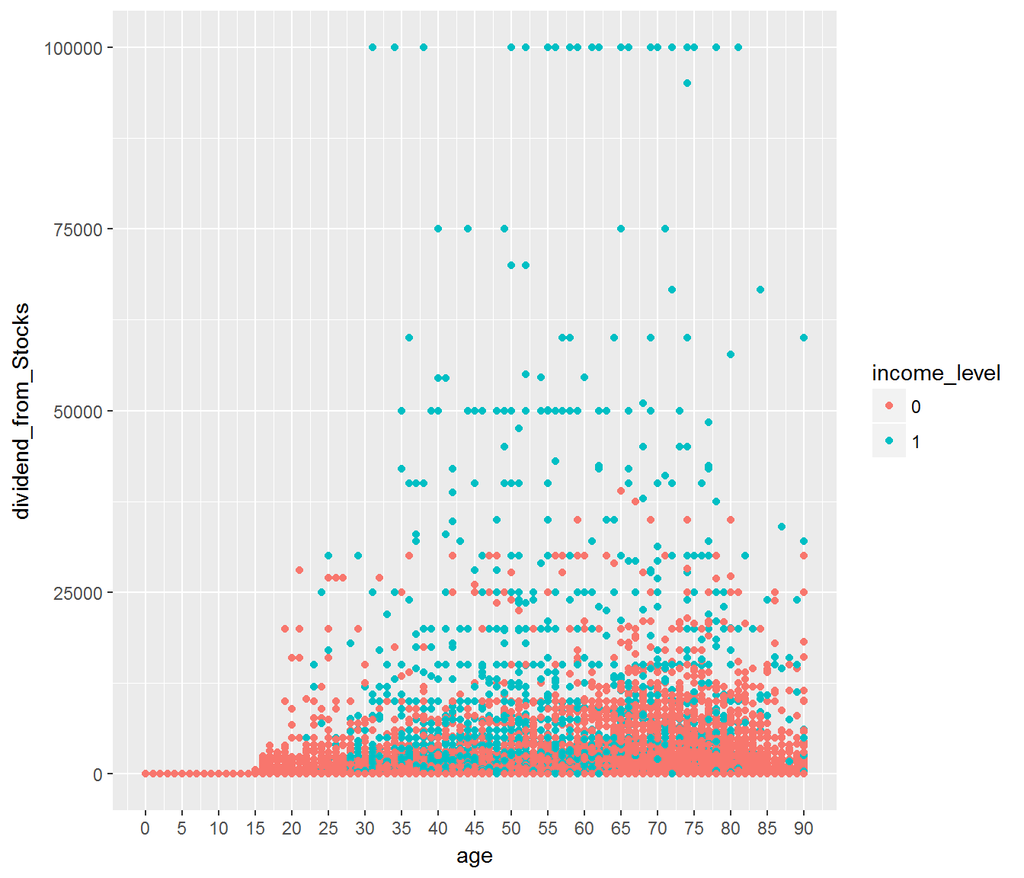

```r
##  age~ dividend_from_Stocks
ggplot(cont_training) +
  geom_point(aes(x = age, y = dividend_from_Stocks, color = income_level)) +
  scale_x_continuous(breaks = seq(0, 100, 5))
```

# IV. Tidy Data

```r
table(is.na(cont_training))
```

```
##
##   FALSE
## 1596184
```

```r
table(is.na(cont_test))
```

```
##
##  FALSE
## 798096
```

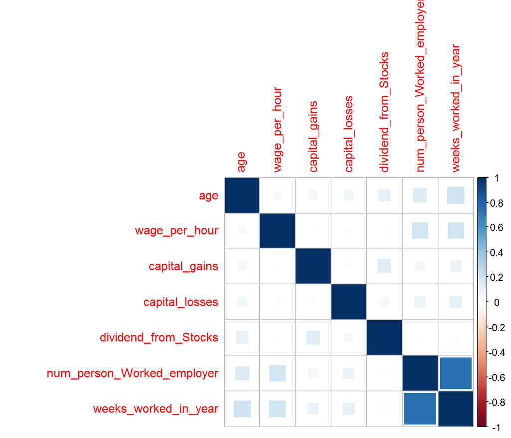

```r
corrplot(cor(cont_training[,1:7]), method = "square")
```

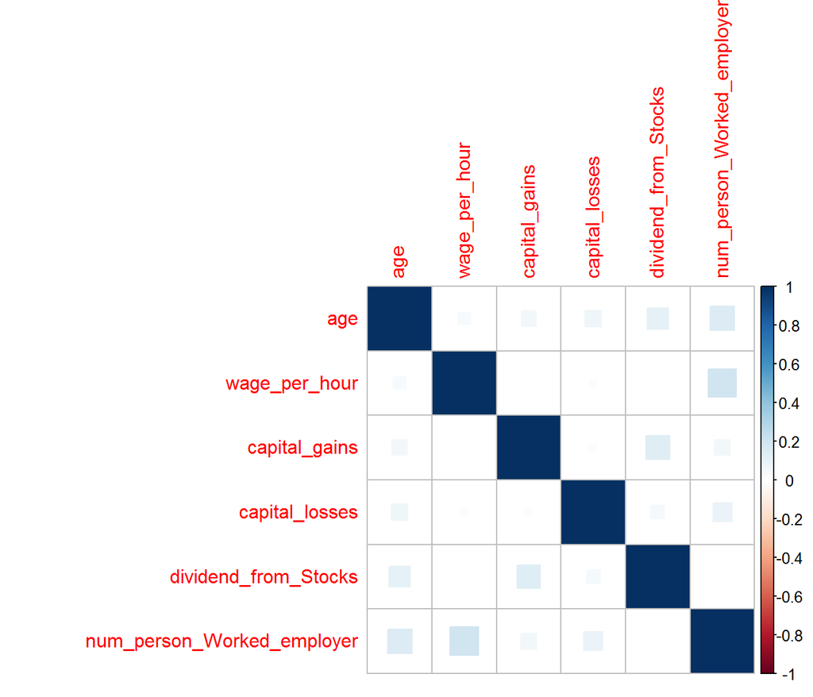

```r
highcor <- findCorrelation(cor(cont_training[, 1:7]), cutoff = 0.6)
cont_training <- cont_training[, -highcor]
corrplot(cor(cont_training[, 1:ncol(cont_training) - 1]), method = "square")
```

```r
## remove this correlated variables from cont_test
cont_test <- cont_test[, -highcor]
```

Now there is no high correlated variables in our training and test dataset

# V. Main Problem

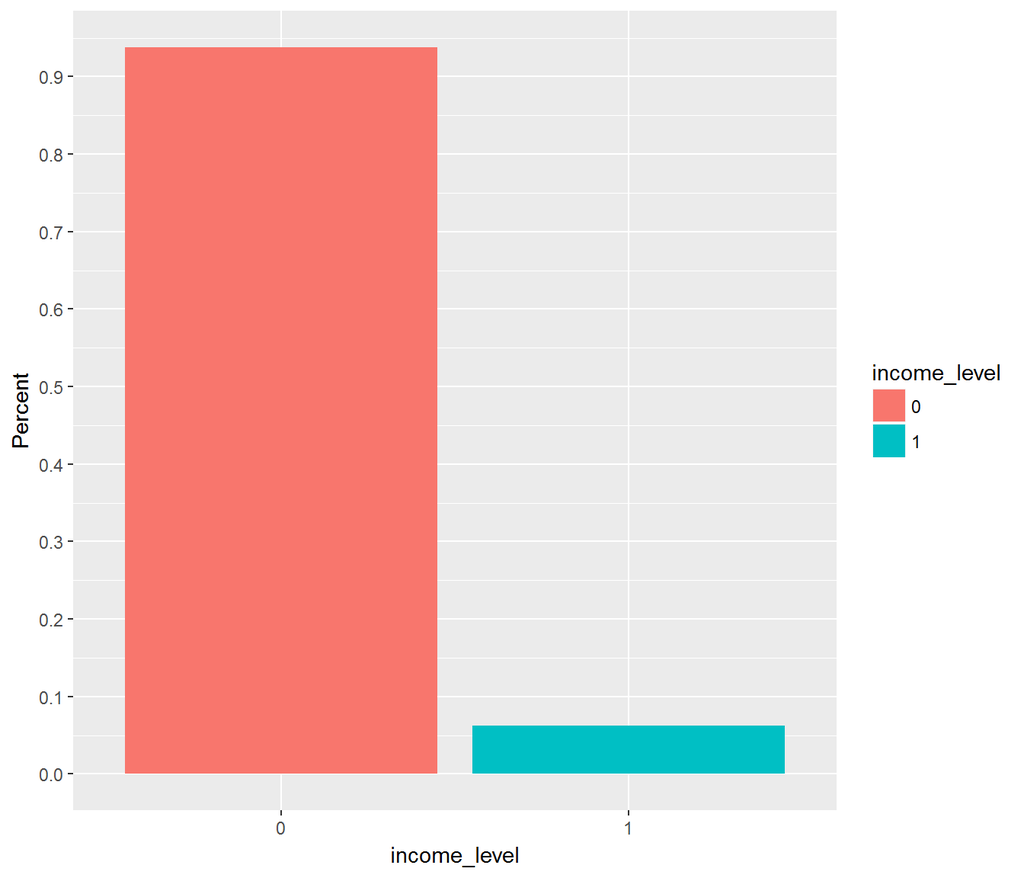

```r
ggplot(training.data) +
  geom_bar(aes(x = income_level, y = (..count..)/sum(..count..), fill = income_level)) +
  scale_y_continuous(breaks = seq(0, 1, 0.1)) +
  ylab("Percent")
```

```r
table(training.data$income_level)
```

```
##
##      0      1
## 187141  12382
```

```r
187141/nrow(training.data) * 100
```

```
## [1] 93.7942
```

According to the bar chart, about 93.8% of people’s income is less than $50000 a year. Hence we can define this dataset as an unbalanced dataset.

```r
train.imb <- rpart(income_level~., data = cont_training)
pred.train <- predict(train.imb, newdata = cont_test)

accuracy.meas(response = test.data$income_level, pred.train[,2])
```

```
##
## Call:
## accuracy.meas(response = test.data$income_level, predicted = pred.train[,
##     2])
##
## Examples are labelled as positive when predicted is greater than 0.5
##
## precision: 0.726
## recall: 0.157
## F: 0.129
```

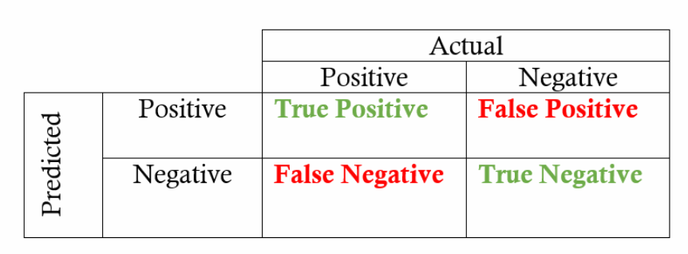

$$Precision = \frac{true \: positives}{true\: positives + false\: positives}$$

$$Recall = \frac{true \: positives}{true \: positives + false\: negatives}$$
We can directly make a prediction to see whether this dataset is good enough or not.

According to the outcome with threshold as 0.5, the precision shows that the prediction make a lot of mistakes, the recall is very low and indicates that we have high number of false negatives. F = 0.129 suggests weak accuracy of this model.

# VI. Resample Data

1. Combind dataset (prepared for NaiveBayes & 10 fold Cross Validation)

```r
train_bind <- cbind(cont_training, nom_training)
test_bind <- cbind(cont_test, nom_test)

train.task <- makeClassifTask(data = train_bind, target = "income_level")
test.task <- makeClassifTask(data = test_bind, target = "income_level")
```

2. Then remove constant data from both datasets.

```r
train.task <- removeConstantFeatures(train.task)
test.task <- removeConstantFeatures(test.task)
```

3. under sample

```r
train_under <- undersample(train.task, rate = 0.1)
table(getTaskTargets(train_under))
```

```
##
##     0     1
## 18714 12382
```

4. over sample

```r
train_over <- oversample(train.task, rate = 15)
table(getTaskTargets(train_over))
```

```
##
##      0      1
## 187141 185730
```

# VII. Machine Learning

## 1. Logistics Regression

### 1) Oversample

```r
cont_training$income_level <- as.factor(cont_training$income_level)
cont_test$income_level <- as.factor(cont_test$income_level)

set.seed(99)
# oversample data
over <- ovun.sample(income_level~., data = cont_training, method = "over")$data

table(over$income_level)
```

```
##
##      0      1
## 187141 186698
```

```r
fit.logit.over <- glm(income_level~., data = over, family = "binomial")
pre1 <- predict(fit.logit.over, cont_test, type = "response")
pred.logit.1 <- ifelse(pre1 < 0.5, "0", "1")

table(cont_test$income_level, pred.logit.1)
```

```
##    pred.logit.1
##         0     1
##   0 70372 23204
##   1  1449  4737
```

```r
# Precision
70372/(70372 + 23204) * 100
```

```
## [1] 75.20304
```

```r
# Recall
70372/(70372 + 1449) * 100
```

```
## [1] 97.98248
```

### 2)Undersample

```r
set.seed(99)

under <- ovun.sample(income_level~., data = cont_training, method = "under")$data

table(under$income_level)
```

```
##
##     0     1
## 12211 12382
```

```r
fit.logit.under <- glm(income_level~., data = under, family = "binomial")
pre2 <- predict(fit.logit.under, cont_test, type = "response")

pred.logit.2 <- ifelse(pre2 < 0.5, "0", "1")

table(cont_test$income_level, pred.logit.2)
```

```
##    pred.logit.2
##         0     1
##   0 69907 23669
##   1  1430  4756
```

```r
# Precision
69907/(69907+23669) * 100
```

```
## [1] 74.70612
```

```r
# Recall
69907/(69907+1430) * 100
```

```
## [1] 97.99543
```

These two resampled dataset really works in Logistics Regression.

However, logistics regression can only be used with continuous variables. Our problem has too many nominal variables.

Therefore, we need to use more concrete methods to make prediction.

## 2. NaiveBayes & Cross Validation

```r
naive_learner <- makeLearner("classif.naiveBayes", predict.type = "response")
naive_learner$par.vals <- list(laplace = 1)

folds <- makeResampleDesc("CV", iters = 10, stratify = TRUE)

fun_cv <- function(a){
  crv_val <- resample(naive_learner,a,folds,measures = list(acc,tp,tn,fp,fn))
  crv_val$aggr
}
```

Print accuracy and other statistical measures of the performance

```r
set.seed(99)
fun_cv(train_under)
```

```
## Resampling: cross-validation
```

```
## Measures:             acc       tp        tn        fp        fn
```

```
## [Resample] iter 1:    0.8025723   1426.00000001070.0000000169.0000000 445.0000000
```

```
## [Resample] iter 2:    0.8086201   1450.00000001064.0000000174.0000000 421.0000000
```

```
## [Resample] iter 3:    0.8102284   1464.00000001055.0000000183.0000000 407.0000000
```

```
## [Resample] iter 4:    0.8169830   1458.00000001082.0000000156.0000000 413.0000000
```

```
## [Resample] iter 5:    0.8063686   1440.00000001067.0000000171.0000000 431.0000000
```

```
## [Resample] iter 6:    0.8045016   1470.00000001032.0000000206.0000000 402.0000000
```

```
## [Resample] iter 7:    0.8221293   1485.00000001071.0000000167.0000000 386.0000000
```

```
## [Resample] iter 8:    0.8176849   1471.00000001072.0000000166.0000000 401.0000000
```

```
## [Resample] iter 9:    0.8003857   1435.00000001055.0000000184.0000000 437.0000000
```

```
## [Resample] iter 10:   0.8131833   1464.00000001065.0000000173.0000000 408.0000000
```

```
## Aggregated Result: acc.test.mean=0.8102657,tp.test.mean=1456.3000000,tn.test.mean=1063.3000000,fp.test.mean=174.9000000,fn.test.mean=415.1000000
```

```
## acc.test.mean  tp.test.mean  tn.test.mean  fp.test.mean  fn.test.mean
##     0.8102657  1456.3000000  1063.3000000   174.9000000   415.1000000
```

```r
set.seed(99)
fun_cv(train_over)
```

```
## Resampling: cross-validation
```

```
## Measures:             acc       tp        tn        fp        fn
```

```
## [Resample] iter 1:    0.8172285    14344.000000016128.00000002445.0000000 4370.0000000
```

```
## [Resample] iter 2:    0.8167726    14334.000000016121.00000002452.0000000 4380.0000000
```

```
## [Resample] iter 3:    0.8184086    14406.000000016110.00000002463.0000000 4308.0000000
```

```
## [Resample] iter 4:    0.8178722    14485.000000016011.00000002562.0000000 4229.0000000
```

```
## [Resample] iter 5:    0.8170189    14436.000000016029.00000002544.0000000 4279.0000000
```

```
## [Resample] iter 6:    0.8163971    14364.000000016077.00000002496.0000000 4350.0000000
```

```
## [Resample] iter 7:    0.8176576    14371.000000016117.00000002456.0000000 4343.0000000
```

```
## [Resample] iter 8:    0.8209564    14534.000000016077.00000002496.0000000 4180.0000000
```

```
## [Resample] iter 9:    0.8165849    14455.000000015993.00000002580.0000000 4259.0000000
```

```
## [Resample] iter 10:   0.8173090    14411.000000016064.00000002509.0000000 4303.0000000
```

```
## Aggregated Result: acc.test.mean=0.8176206,tp.test.mean=14414.0000000,tn.test.mean=16072.7000000,fp.test.mean=2500.3000000,fn.test.mean=4300.1000000
```

```
## acc.test.mean  tp.test.mean  tn.test.mean  fp.test.mean  fn.test.mean
##  8.176206e-01  1.441400e+04  1.607270e+04  2.500300e+03  4.300100e+03
```

# VIII. Conclusion

> Data Separation is required to remove high correlated variables;

> For Imbalanced Data:
> 1. Ignoring the problem;
> 2. Undersampling the majority class;
> 3. Oversampling the minority class: